# Project 7

bigMACs

2022-11-27

### Introduction

The purpose of this study was to examine the force-length relationship of muscles of the forearm, and determine the shift of this relationship when the muscles are fatigued and when they are not. According to previous studies completed,“there was a significant shift in the peak torque angle to longer muscle lengths in the eccentrically-exercised leg immediately and on the following two days after exercise when compared with baseline (Yeung and Yeung 2008). This hypothesis is to be confirmed in this study by collecting class-wide data from both fatigued and non-fatigued muscles, and the resulting shift was analyzed.

### Methods

For this project we wanted to explore the effect of length on muscle force and generation and factor in how fatigue may or may not affect this relationship of FxL. We gain mechanical advantage from the overlapping of myosin-actin cross bridges in the formula MA=Lever input/ lever output. In this experiment we will be measuring the isometric force over the range of motion of the forearm, MVC. To gather this data of MVC we designed an experiment using an Arduino Sensor, or an Arduino-based force-data acquisition device.

For the isokinetic eccentric drops, the tester would need to fatigue their testing arm. Using a book bag and passing it to the fully extended arm, the experimenter would hold it for three seconds before flexing the arm. This cycle would occur for around 3 minutes until the forearm was fatigued. After waiting two minutes, the tester would then repeat the exact experiment for the control.

We took the maximum force recorded during each trial for each individual plus condition and normalized it based on their true maximum force across all angles. The normalized maximum forces are then used along with the tested angles to analyze the force-length relationship. To record accurate relationships and maximum force producing angles, we fit the best polynomial model for each trial under AIC conditions. The max force angles under fatigue and control conditions were used to calculate the mean shift between the two conditions. The significance of this shift was also tested using ANOVA.

### Results

#### Exploring Force Length Relationships

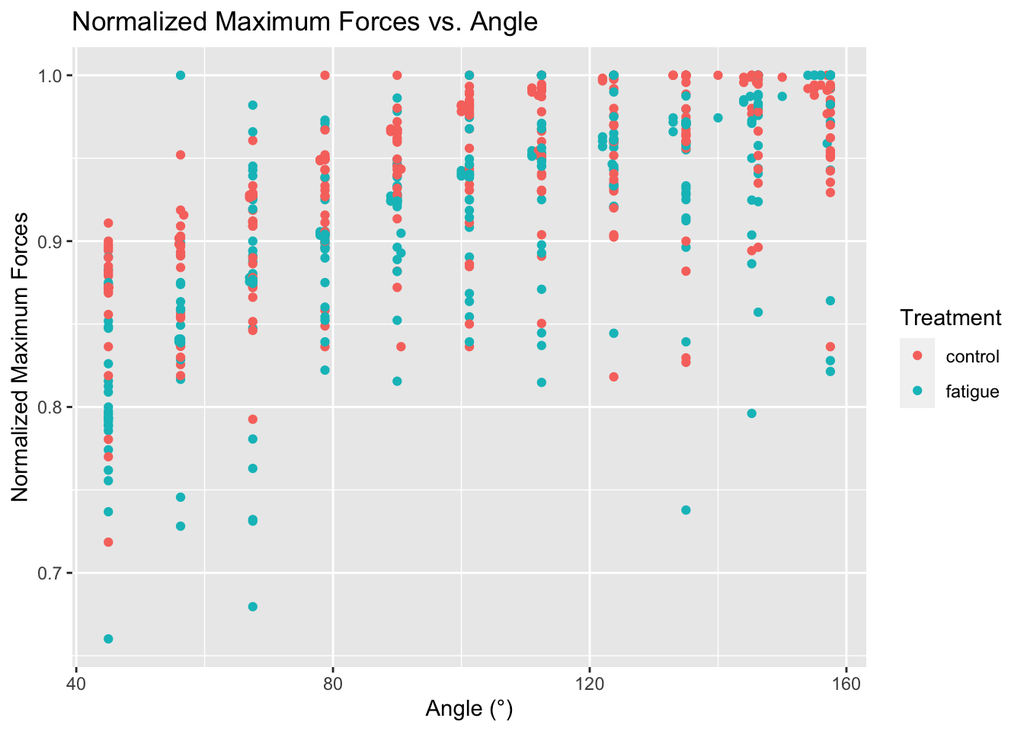

Figure 1: The normalized maximum forces produced by each individual under each condition (control or fatigue) across all tested angles between 45° to 157.5°

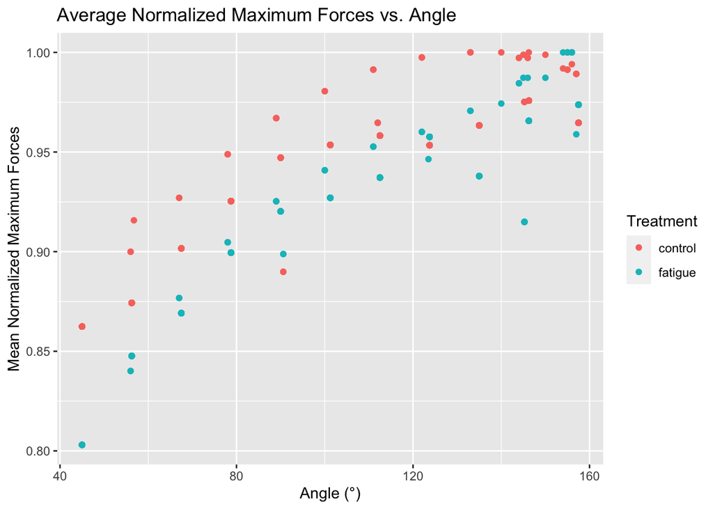

Figure 2: The force length relationship displayed as mean normalized maximum forces produced at each angle and categorized by the treatment.

When we clean up the data by taking the sample mean of the normalized maximum forces, the trend is clearer. Under control conditions, the force-length relationship curve appears to peak at around 140°. Under fatigue conditions, the force-length relationship curve is still very noisy, because not not all subjects took their data at the same angles, some angle observations are only based on a couple of individuals. But it would appear that the peak occurs around 155°, just before a drop off at the end of the range. A typical force-length relationship would have the maximum output at an intermediate angle. For our study, we would expect that to be at 101.25°. However, both under control and fatigue treatments, our subjects produced a force-length relationship peak at a higher than expected angle.

#### Force-Length Relationship Shift

```
## # A tibble: 1 × 2
##   mean.shift se.shift
##        <dbl>    <dbl>
## 1       8.65     4.35
```

Based on the best polynomial models, we calculated a mean shift of 8.65° in the maximum force producing angle between the fatigue treatment and the control treatment. This means there was an upwards shift in the force-length relationship when moving from control to fatigued muscles. Although the shift is sizable, the standard error is also relatively high at 4.35°. While we have controlled for individual differences by having subjects conduct both control and fatigue treatments, there are still a number of reasons for the high variance such as small sample sizes at specific angles or varying measuring techniques which can bias the trend and the calculations.

```
## Analysis of Variance Table
##
## Response: theta_max
##           Df  Sum Sq Mean Sq F value Pr(>F)
## Activity   1   886.3  886.27   4.321 0.0425 *
## Residuals 53 10870.7  205.11
## ---
## Signif. codes:  0 '***' 0.001 '**' 0.01 '*' 0.05 '.' 0.1 ' ' 1
```

When we ran an ANOVA variance test between the maximum force producing angle and the treatment, we found that the relationship, hence the shift in force-length relationship is statistically significant at the 5% level.

### Discussion

The force-length relationship is a fundamental property of skeletal muscles. It signifies that the greatest force is outputted at its ideal/resting length, and the least force is generated when the muscle is stretched or shortened past this ideal length. This project explored the effect of length on muscle force generation, specifically the impact of fatigue on the FL relationship of the human upper limbs. Previous research has demonstrated that the FL relationship shifts promptly and long after eccentric fatigue (Yeung and Yeung 2008).

Our class wide study found a mean shift of 8.65 degrees in the maximum force-producing angle between the fatigue and control treatments. These findings demonstrated an apparent upwards shift in the FL relationships when moving from the controlled to tired muscles. This shift was statistically significant at the 5% level, as confirmed through an ANOVA variance test. This data provides further analysis of human movement and muscle function, specifically upper arm biomechanics.

Further studies could be undergone exploring this relationship to find the effect of force and the length over a larger period of time. Studies could determine which angle/length fatigues muscles at a faster rate or even examine how these angles impact the recovery times of specific muscles. A previous study examined a similar relationship and found that the shift in the angle-force curve was proportional to the degrees of muscle damage. This study aimed to explore and compare the magnitude and time course of the change in the angle-force curves, both before and four consecutive days after eccentric and isometric exercise (Philippou et al. 2004). Further studies between fatigue and time within the FL relationship could point to an optimal angle/length and time to work a specific muscle, enhancing individuals’ physical therapy and recovery times.

### Contributions

Introduction: Samantha

Methods: John

Results/Code: Philip

Discussion: Jack

### References

Philippou, Anastassios, Gregory C Bogdanis, Alan M Nevill, and Maria Maridaki. 2004. “Changes in the Angle-Force Curve of Human Elbow Flexors Following Eccentric and Isometric Exercise.” *European Journal of Applied Physiology* 93 (1): 237–44.

Yeung, SS, and EW Yeung. 2008. “Shift of Peak Torque Angle After Eccentric Exercise.” *International Journal of Sports Medicine* 29 (03): 251–56.